# Exercise 2 (20 minutes)

You practice: standard errors, t- and p-values, and confidence intervals. When you're done, assist some of the others …

Now the same logic, on **trust in the legal system** (`trstlgl`). Keep the prepared `ESS` from Exercise 1 (its "Stuck?" box still applies).

1. **Write it yourself:** regress trust in the legal system on years of education, **with weights**, and look at the full results with `tidy()`.

```r
mod <- lm_robust(trstlgl ~ eduyrs, data = ESS, weights = pspwght)
tidy(mod) # Estimate, standard error, t-value, p-value and 95% CI
#          term estimate std.error statistic p.value conf.low conf.high   df outcome
# 1 (Intercept)    6.135     0.287      21.4 5.2e-89    5.573      6.70 1509 trstlgl
# 2      eduyrs    0.099     0.019       5.2 2.0e-07    0.062      0.14 1509 trstlgl
```

2. Read off the estimated slope $\hat\beta$: one more year of education goes with a change in legal-system trust of (three digits; point or comma is fine).
3. What is its estimated **standard error** $\hat\sigma$?
4. The **$t$-value** here is about 5.2. What does it tell you?
5. And the **$p$-value**? Which reading is correct?
6. **Predict, then check.** With $p =$ 2e-07, at the conventional 5% threshold we …
7. **Write two sentences** (as `# comments`): (a) can we reject $H_0$, and (b) does that make the effect *causal*? Then compare:

*(a) Yes: p is well below 0.05, so we reject the null of no association — better-educated Danes trust the legal system significantly more. (b) No — this is a significant **association** in observational survey data. Significance rules out chance, not confounding: more-educated people differ in many other ways too. Causal claims need the designs we meet later in the course.*

8. Visualise it: make a scatter plot of `trstlgl` on `eduyrs` with a weighted OLS line and its **95% confidence band**, and map the weights to dot size.

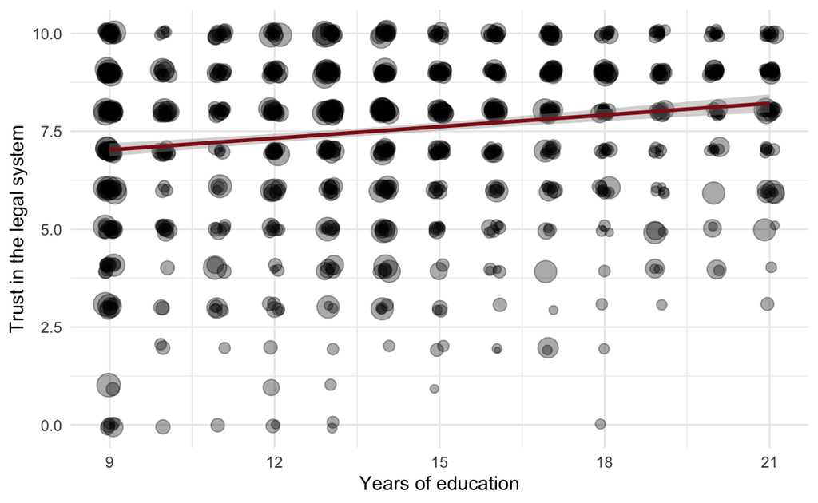

```r
ggplot(ESS, aes(y = trstlgl, x = eduyrs)) +
  geom_jitter(aes(size = pspwght), alpha = 1/3, height = 0.1, width = 0.1) +
  geom_smooth(aes(weight = pspwght), method = "lm", color = "#901A1E") +
  labs(y = "Trust in the legal system", x = "Years of education") +
  theme_minimal() +
  theme(legend.position = "none")
```

**Bonus (for the fast):** re-estimate the model on a **random sample of 50** respondents (`ESS %>% sample_n(50)`). Is the slope still significant? Run it a few times (without `set.seed`) — what does that teach you about sample size and sampling error?

```r
mod_small <- lm_robust(trstlgl ~ eduyrs, data = ESS %>% sample_n(50))
tidy(mod_small) %>% filter(term == "eduyrs") %>%
  select(estimate, std.error, statistic, p.value)
#   estimate std.error statistic p.value
# 1    0.083      0.05       1.6    0.11
```

With only 50 people the standard error is large, so the estimate usually is **not** significant — and it jumps around from run to run. The full-sample effect is real, but a tiny sample rarely has the *power* to detect it. **More data → smaller standard error → sharper conclusions.**